# Measuring association

## Association = Probabilistic relationship

| Scenario | Formally | Implication (meaning) |
| --- | --- | --- |
| Independent | Pr(Y\|X) = Pr(Y) | Distibution of Y is equal for all X |
| Related | Pr(Y\|X) \(\ne\) Pr(Y) | Distribution of Y is NOT equal for all X |

Cases:

- X and Y are both categorical
- One of each type
- X and Y are both quantitative

## Independence

Distibution of Y is equal for all X

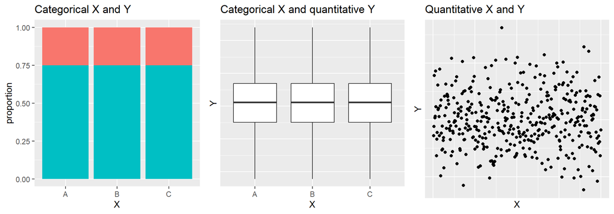

Any other pattern is non-independence (association)

## Association measures/analysis

| Variables | Measures/analysis |
| --- | --- |
| Categorical (both) | chi-square, RD, RR, OR, NNT |
| One quantitative and one categorical | mean difference |
| Quantitative (both) | covariance, correlation coefficients |

## Quantitative X and Y: Covariance

Differences wrt the mean of each variable

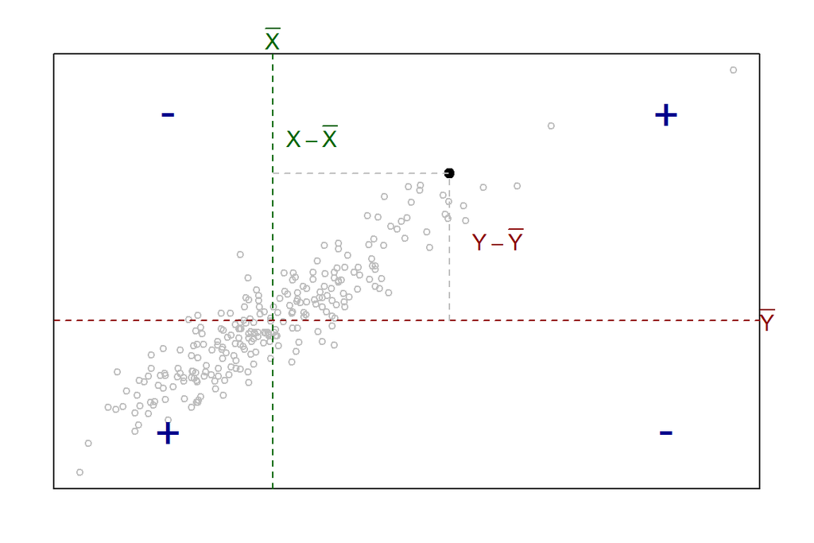

Covariance(X,Y) = \(\frac{1}{n-1} \sum{(X-\bar{X}) \times (Y-\bar{Y})}\)

## Covariance

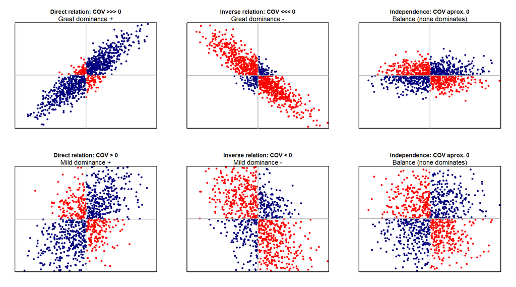

## Covariance: limitations

Has dimension: units of \(X\) \(\times\) units of \(Y\)

Therefore, its value depends on units (scale), which is undesirable

Not easy to decide if relation is mild, or strong…

Solution: get rid of units

## Correlation coefficients

Pearson’s \(r\): \(\quad \frac{Cov(X,Y)}{S_X S_Y} \qquad\) measures *linear* relation (not *any kind of* relation!)

Spearman’s \(r_s\): \(\quad\) Pearson’s \(r\) of the *ranks* of X and Y

- Both are dimensionless, with range -1 to +1
- Care with non-linearities and outliers, ALWAYS inspect scatterplot:
  - linear relation with no outliers: Pearsons \(r\)
  - outliers, or non-linear but *monotonic*: Spearman’s \(r_s\)
  - non-linear, non-monotonic: neither!

## Patterns of relationship

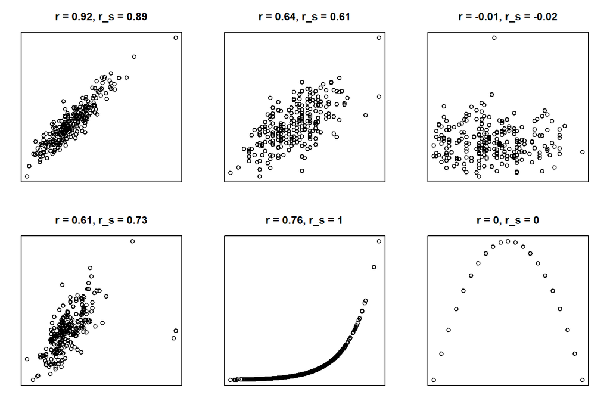

## Correlation coefficients in R

```r
mosaic::cor(var1 ~ var2, data = dataframe)                           # Pearson

mosaic::cor(var1 ~ var2, data = dataframe, method = "spearman")


# test of (linear) independence
mosaic::cor.test(var1 ~ var2, data = dataframe)

mosaic::cor.test(var1 ~ var2, data = dataframe, method = "spearman")

# Spearman test with ties
mosaic::cor.test(var1 ~ var2, data = dataframe, method = "spearman", exact=FALSE)
```

## Exercise

Is it reasonable to expect the weight at birth to be related to the mothers weight? If yes, do you expect a direct or an inverse relation? Use the birthwt dataset in package MASS to:

- Compute a new variable expressing the weight of mothers in kilograms (lwt_kg).
- Investigate if birthweights are related to the mother’s weights.
- Compute the Pearson’s and the Spearman’s correlation coefficients. Which one would you choose and why?
- Test the null hypothesis that the correlation is zero in the population. Since a direct relation is expected conduct a one-sided test (see the help of the function to learn how to specify the appropriate alternative hypothesis).
- What is the p-value? Does it provide evidence of a direct relation of birthweight and the mother’s weight?